# 1번 문제

### (1) customer 데이터를 k-means clustering 모델을 활용하여 4개의 그룹으로 군집화하세요.

- mall_customer 데이터 불러오기
- 성별(Gender)을 남자는 0, 여자는 1로 변환하기.
- 4개의 군집으로 clustering하기.

```python
import pandas as pd
import numpy as np
import matplotlib.pyplot as plt
%matplotlib inline
from sklearn.cluster import KMeans
from sklearn.preprocessing import StandardScaler
```

```python
customer=pd.read_csv('mall_customers.csv')
customer
```

|  | CustomerID | Gender | Age | Annual Income (k$) | Spending Score (1-100) |
| --- | --- | --- | --- | --- | --- |
| 0 | 1 | Male | 19 | 15 | 39 |
| 1 | 2 | Male | 21 | 15 | 81 |
| 2 | 3 | Female | 20 | 16 | 6 |
| 3 | 4 | Female | 23 | 16 | 77 |
| 4 | 5 | Female | 31 | 17 | 40 |
| ... | ... | ... | ... | ... | ... |
| 195 | 196 | Female | 35 | 120 | 79 |
| 196 | 197 | Female | 45 | 126 | 28 |
| 197 | 198 | Male | 32 | 126 | 74 |
| 198 | 199 | Male | 32 | 137 | 18 |
| 199 | 200 | Male | 30 | 137 | 83 |

200 rows × 5 columns

```python
customer['Gender'].replace(['Male','Female'],[0,1],inplace=True)
kmeans=KMeans(n_clusters=4, init='k-means++',max_iter=300,random_state=0)
kmeans.fit(customer)
customer['cluster']=kmeans.labels_
print(kmeans.labels_)
```

```
[0 0 0 0 0 0 0 0 0 0 0 0 0 0 0 0 0 0 0 0 0 0 0 0 0 0 0 0 0 0 0 0 0 0 0 0 0
 0 0 0 0 0 0 0 0 0 0 0 0 0 0 0 0 0 0 0 0 2 0 2 2 0 2 2 2 2 2 2 2 2 2 2 2 2
 2 2 2 2 2 2 2 2 2 2 2 2 2 2 2 2 2 2 2 2 2 2 2 2 2 2 2 2 2 2 2 2 2 2 2 2 2
 2 2 2 2 2 2 2 2 2 2 2 2 1 2 1 2 1 3 1 3 1 3 1 3 1 3 1 3 1 3 1 3 1 3 1 3 1
 3 1 3 1 3 1 3 1 3 1 3 1 3 1 3 1 3 1 3 1 3 1 3 1 3 1 3 1 3 1 3 1 3 1 3 1 3
 1 3 1 3 1 3 1 3 1 3 1 3 1 3 1]
```

#### (2) (1)에서 수행한 customer 군집를 시각화하세요.

- 2차원 평면에 나타내기 위해 pca를 사용하여 2개의 주성분 구하기.
- 각 주성분 값을 인덱스로 지정하고, scatter plot 그리기.

```python
from sklearn.decomposition import PCA
```

```python
pca=PCA(n_components=2)
pca_transformed=pca.fit_transform(customer)
customer['pca_x']=pca_transformed[:,0]
customer['pca_y']=pca_transformed[:,1]
customer.head()
```

|  | CustomerID | Gender | Age | Annual Income (k$) | Spending Score (1-100) | cluster | pca_x | pca_y |
| --- | --- | --- | --- | --- | --- | --- | --- | --- |
| 0 | 1 | 0 | 19 | 15 | 39 | 0 | -109.392502 | 5.478653 |
| 1 | 2 | 0 | 21 | 15 | 81 | 0 | -108.213197 | -34.924904 |
| 2 | 3 | 1 | 20 | 16 | 6 | 0 | -107.383609 | 37.835061 |
| 3 | 4 | 1 | 23 | 16 | 77 | 0 | -106.018096 | -30.557086 |
| 4 | 5 | 1 | 31 | 17 | 40 | 0 | -104.989062 | 7.295784 |

[figure not shown]

```python
marker0_ind = customer[customer['cluster']==0].index
marker1_ind = customer[customer['cluster']==1].index
marker2_ind = customer[customer['cluster']==2].index

plt.scatter(x=customer.loc[marker0_ind,'pca_x'], y=customer.loc[marker0_ind,'pca_y'], marker='o')
plt.scatter(x=customer.loc[marker1_ind,'pca_x'], y=customer.loc[marker1_ind,'pca_y'], marker='s')
plt.scatter(x=customer.loc[marker2_ind,'pca_x'], y=customer.loc[marker2_ind,'pca_y'], marker='^')

plt.xlabel('PCA 1')
plt.ylabel('PCA 2')
plt.title('3 Clusters Visualization by 2 PCA Components')
plt.show()
```

# 2번 문제

### (1) make_blobs를 적용한 뒤 데이터 세트와 군집 분포 확인하세요.

- 생성할 총 데이터 수 : 300
- 데이터의 피처 수 : 2
- 군집 수 : 5
- 생성될 군집 데이터의 표준편차 : 0.8, 1.1, 1.2, 0.4, 0.5 순서대로 이용
- random_state = 0

```python
from sklearn.datasets import make_blobs
```

```python
X, y = make_blobs(n_samples=300, n_features=2, centers=5, cluster_std=[0.8,1.1,1.2,0.4,0.5], random_state=0)
print(X.shape, y.shape)
unique, counts = np.unique(y, return_counts=True)
print(unique, counts)
```

```
(300, 2) (300,)
[0 1 2 3 4] [60 60 60 60 60]
```

### (2) 생성된 데이터 셋을 데이터프레임으로 변경하세요. (피처의 이름은 ftr1, ftr2)

```python
clusterDF=pd.DataFrame(data=X,columns=['ftr1','ftr2'])
clusterDF['target']=y
clusterDF.head(3)
```

|  | ftr1 | ftr2 | target |
| --- | --- | --- | --- |
| 0 | 9.823397 | -1.682159 | 4 |
| 1 | -0.796818 | 8.033860 | 3 |
| 2 | 0.420616 | 4.184080 | 0 |

### (3) make_blobs()으로 만든 피처 데이터 세트의 군집화 분포 확인하세요

- markers = ['o','s', '^', 'P', 'D'] 이용하세요

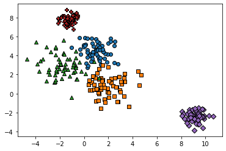

```python
target_list = np.unique(y)

markers=['o', 's', '^', 'P', 'D']

for target in target_list:
    target_cluster = clusterDF[clusterDF['target']==target]
    plt.scatter(x=target_cluster['ftr1'], y=target_cluster['ftr2'], edgecolor='k', marker=markers[target])
plt.show()
```

### (4) Kmeans 군집화를 수행하세요

- n_clusters = 5, init = 'k-means++', max_iter=200, random_state=0
- Target과 cluster 매핑 결과 확인하세요

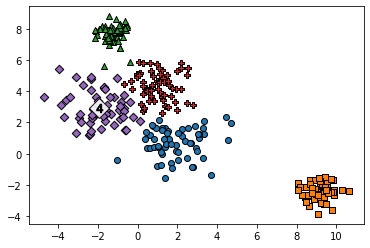

```python
kmeans = KMeans(n_clusters=5, init='k-means++', max_iter=200, random_state=0)
cluster_labels = kmeans.fit_predict(X)
clusterDF['kmeans_label'] = cluster_labels

centers = kmeans.cluster_centers_
unique_labels = np.unique(cluster_labels)
markers=['o', 's', '^', 'P','D','H','x']

for label in unique_labels:
    label_cluster = clusterDF[clusterDF['kmeans_label']==label]
    center_x_y = centers[label]
    plt.scatter(x=label_cluster['ftr1'], y=label_cluster['ftr2'], edgecolor='k', marker=markers[label] )

plt.scatter(x=center_x_y[0], y=center_x_y[1], s=200, color='white', alpha=0.9, edgecolor='k', marker=markers[label])
plt.scatter(x=center_x_y[0], y=center_x_y[1], s=70, color='k', edgecolor='k', marker='$%d$' % label)
plt.show()
```

```python
print(clusterDF.groupby('target')['kmeans_label'].value_counts())
```

```
target  kmeans_label
0       3               58
        2                1
        4                1
1       0               57
        3                3
2       4               55
        0                2
        3                2
        2                1
3       2               60
4       1               60
Name: kmeans_label, dtype: int64
```

# 3번 문제

### 1) Customer 데이터에 대해 SSE와 Silhouette_score 그래프를 통해 최적의 군집범위를 도출하세요.

- 주의사항: 위의 customer 데이터프레임을 그대로 사용할 시, 추가한 열들이 하나의 속성으로 인식될 수 있으므로 원본 데이터를 .copy()하는 방식을 추천

```python
from sklearn.metrics import silhouette_samples, silhouette_score
```

```python
copy=customer.copy()
score_samples=silhouette_samples(copy,copy['cluster'])
copy['silhouette_coeff']=score_samples
```

```python
average_score = silhouette_score(copy, copy['cluster'])
print('Customer 데이터셋 Silhouette Analysis Score:{0:.3f}'.format(average_score))
copy.groupby('cluster')['silhouette_coeff'].mean()
```

```
Customer 데이터셋 Silhouette Analysis Score:0.441
```

```
cluster
0    0.357536
1    0.471470
2    0.483129
3    0.466015
Name: silhouette_coeff, dtype: float64
```

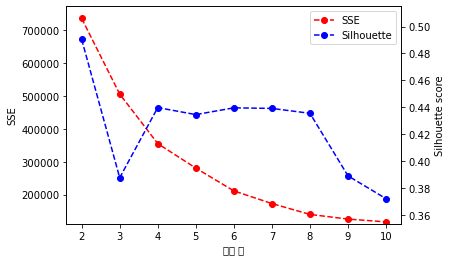

```python
wss = []
sis = []
for k in range(2,11):
    kmeans = KMeans(n_clusters=k, random_state=0)
    kmeans.fit(customer)
    wss = np.append(wss, kmeans.inertia_)
    sis = np.append(sis, silhouette_score(customer, kmeans.labels_))

fig, ax1 = plt.subplots()
ax2 = ax1.twinx()

line1 = ax1.plot(np.arange(2,11), wss, 'ro--', label='SSE')
line2 = ax2.plot(np.arange(2,11), sis, 'bo--', label='Silhouette')

ax1.set_ylim(wss.min()*0.95, wss.max()*1.05)
ax2.set_ylim(sis.min()*0.95, sis.max()*1.05)

ax1.set_xlabel('군집 수')
ax1.set_ylabel('SSE')
ax2.set_ylabel('Silhouette score')

lines = line1 + line2
labels = [l.get_label() for l in lines]

plt.legend(lines, labels)
plt.show()
```

### (2) 최적의 군집범위 내에서 Silhouette 그래프를 활용해 최적의 군집 수를 도출하세요.

- from yellowbrick.cluster import silhouette_visualizer 을 사용
- 파라미터: silhouette_visualizer(KMeans(군집의 개수, random_state=0), 데이터, colors = 'yellowbrick')

```python
import yellowbrick
from yellowbrick.cluster import silhouette_visualizer
```

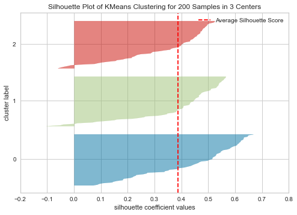

```
SilhouetteVisualizer(ax=<matplotlib.axes._subplots.AxesSubplot object at 0x000001FF7CA50040>,
                     colors='yellowbrick', model=None)
```

```python
silhouette_visualizer(KMeans(3, random_state=0), customer, colors = 'yellowbrick')
```

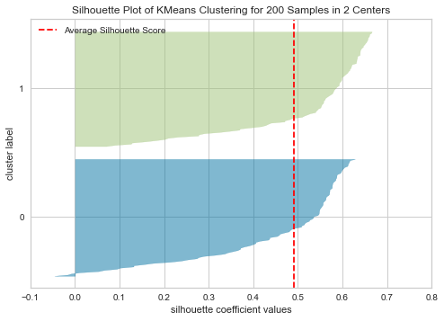

```
SilhouetteVisualizer(ax=<matplotlib.axes._subplots.AxesSubplot object at 0x000001FF7CA194C0>,
                     colors='yellowbrick', model=None)
```

```python
silhouette_visualizer(KMeans(2, random_state=0), customer, colors = 'yellowbrick')
```

```python
def visualize_silhouette(cluster_lists, X_features):
    import matplotlib.cm as cm
    import math

    n_cols = len(cluster_lists)

    fig, axs=plt.subplots(figsize=(4*n_cols, 4), nrows=1, ncols=n_cols)

    for ind, n_cluster in enumerate(cluster_lists):
        clusterer = KMeans(n_clusters = n_cluster, max_iter=500, random_state=0)
        cluster_labels = clusterer.fit_predict(X_features)

        sil_avg = silhouette_score(X_features, cluster_labels)
        sil_values = silhouette_samples(X_features, cluster_labels)

        y_lower = 10
        axs[ind].set_title('Number of Cluster : '+str(n_cluster)+'\n'\
                           'Silhouette Score :' +str(round(sil_avg,3)))
        axs[ind].set_xlabel("The silhouette coefficient values")
        axs[ind].set_ylabel("Cluster label")
        axs[ind].set_xlim([-0.1, 1])
        axs[ind].set_ylim([0, len(X_features) + (n_cluster + 1) * 10])
        axs[ind].set_yticks([])
        axs[ind].set_xticks([0, 0.2, 0.4, 0.6, 0.8, 1])

        for i in range(n_cluster):
            ith_cluster_sil_values = sil_values[cluster_labels==i]
            ith_cluster_sil_values.sort()

            size_cluster_i = ith_cluster_sil_values.shape[0]
            y_upper = y_lower + size_cluster_i

            color = cm.nipy_spectral(float(i) / n_cluster)
            axs[ind].fill_betweenx(np.arange(y_lower, y_upper), 0, ith_cluster_sil_values, \
                                   facecolor=color, edgecolor=color, alpha=0.7)
            axs[ind].text(-0.05, y_lower + 0.5 * size_cluster_i, str(i))
            y_lower = y_upper + 10

        axs[ind].axvline(x=sil_avg, color="red", linestyle="--")
```

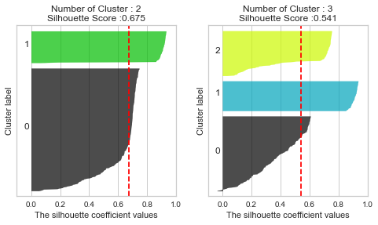

```python
visualize_silhouette([2,3], X)
```

# 4번 문제

### (1) Annual Income열과 Spending Score 열만 추출한 후 정규화 해주세요.

```python
from sklearn.preprocessing import MinMaxScaler
scaler=MinMaxScaler()
```

```python
temp=customer['Annual Income (k$)'].values
temp
customer['Annual Income (k$)']=scaler.fit_transform(temp.reshape(-1,1))
temp=customer['Spending Score (1-100)'].values
temp
customer['Spending Score (1-100)']=scaler.fit_transform(temp.reshape(-1,1))
customer.head()
```

|  | CustomerID | Gender | Age | Annual Income (k$) | Spending Score (1-100) | cluster | pca_x | pca_y |
| --- | --- | --- | --- | --- | --- | --- | --- | --- |
| 0 | 1 | 0 | 19 | 0.000000 | 0.387755 | 0 | -109.392502 | 5.478653 |
| 1 | 2 | 0 | 21 | 0.000000 | 0.816327 | 0 | -108.213197 | -34.924904 |
| 2 | 3 | 1 | 20 | 0.008197 | 0.051020 | 0 | -107.383609 | 37.835061 |
| 3 | 4 | 1 | 23 | 0.008197 | 0.775510 | 0 | -106.018096 | -30.557086 |
| 4 | 5 | 1 | 31 | 0.016393 | 0.397959 | 0 | -104.989062 | 7.295784 |

### (2) estimate_bandwidth를 이용하여 최적의 대역폭을 구한 후 그에 따른 군집화의 분류 개수를 구하세요

```python
from sklearn.cluster import MeanShift
from sklearn.cluster import estimate_bandwidth
```

```python
best_bandwidth = estimate_bandwidth(X)
meanshift= MeanShift(bandwidth=best_bandwidth)
cluster_labels = meanshift.fit_predict(X)

print('cluster labels 유형:', np.unique(cluster_labels))
```

```
cluster labels 유형: [0 1]
```

### (3) bandwidth 값을 0.95로 설정하여 도출된 군집을 시각화하세요

```
cluster labels 유형: [ 0  1  2  3  4  5  6  7  8  9 10 11 12 13 14 15 16 17 18]
```

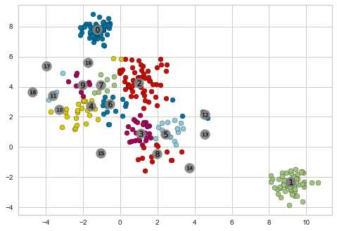

```python
meanshift= MeanShift(bandwidth=0.95)
cluster_labels = meanshift.fit_predict(X)

clusterDF['meanshift_label'] = cluster_labels
centers = meanshift.cluster_centers_
unique_labels = np.unique(cluster_labels)

print('cluster labels 유형:', np.unique(cluster_labels))

for label in unique_labels:
    label_cluster = clusterDF[clusterDF['meanshift_label']==label]
    center_x_y = centers[label]

    plt.scatter(x=label_cluster['ftr1'], y=label_cluster['ftr2'], edgecolor='k', marker='o')

    plt.scatter(x=center_x_y[0], y=center_x_y[1], s=200, color='gray', alpha=0.9, marker='o')
    plt.scatter(x=center_x_y[0], y=center_x_y[1], s=70, color='k', edgecolor='k', marker='$%d$' % label)

plt.show()
```

```python
print(clusterDF.groupby('target')['meanshift_label'].value_counts())
```

```
target  meanshift_label
0       2                  51
        6                   3
        7                   3
        16                  2
        12                  1
1       3                  23
        5                  16
        8                  12
        2                   3
        12                  3
        14                  2
        13                  1
2       4                  16
        6                  12
        9                   9
        10                  9
        7                   4
        11                  3
        17                  2
        2                   1
        3                   1
        15                  1
        16                  1
        18                  1
3       0                  60
4       1                  60
Name: meanshift_label, dtype: int64
```